# Frequentist Statistical Test Selection

Nathan Ormond

2025-03-15

## Introduction

This document demonstrates how to select appropriate frequentist statistical tests based on your data characteristics and research questions. We’ll use standard R packages instead of specialized flowchart packages.

## Basic Statistical Test Selection Framework

The selection of an appropriate statistical test follows a logical decision tree based on three fundamental considerations:

1. **Data characteristics** (categorical vs continuous)
2. **Research question structure** (comparison vs relationship)
3. **Assumption verification** (normality, equal variances, etc.)

Let’s visualize these decision points:

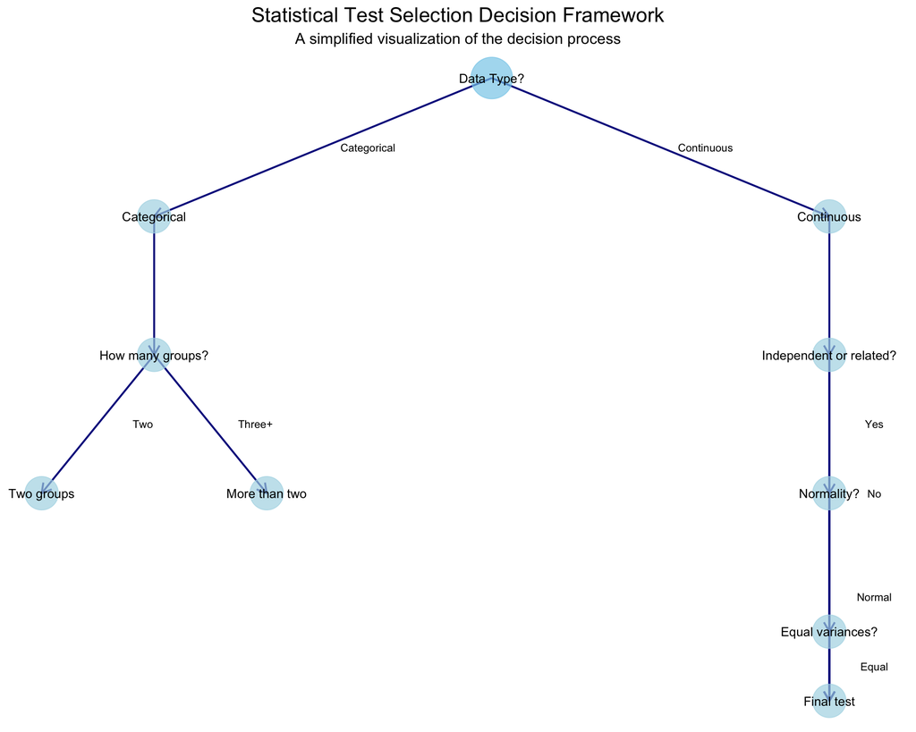

```r
# Create data for a basic decision tree visualization
nodes <- data.frame(
  id = 1:10,
  label = c("Data Type?", "Categorical", "Continuous", "How many groups?",
            "Two groups", "More than two", "Independent or related?",
            "Normality?", "Equal variances?", "Final test"),
  x = c(5, 2, 8, 2, 1, 3, 8, 8, 8, 8),
  y = c(10, 8, 8, 6, 4, 4, 6, 4, 2, 1)
)

# Create edges connecting the nodes
edges <- data.frame(
  from = c(1, 1, 2, 4, 4, 3, 7, 7, 8, 8, 9, 9),
  to = c(2, 3, 4, 5, 6, 7, 8, 9, 10, 10, 10, 10),
  label = c("Categorical", "Continuous", "", "Two", "Three+", "",
            "Yes", "No", "Normal", "Non-normal", "Equal", "Unequal")
)

# Create a visual representation of the decision tree
ggplot() +
  # Draw edges as arrows
  geom_segment(data = edges, aes(x = nodes$x[from], y = nodes$y[from],
                                  xend = nodes$x[to], yend = nodes$y[to]),
               arrow = arrow(length = unit(0.3, "cm")),
               color = "darkblue", size = 0.7) +
  # Add edge labels
  geom_text(data = edges, aes(x = (nodes$x[from] + nodes$x[to])/2,
                              y = (nodes$y[from] + nodes$y[to])/2,
                              label = label),
            size = 3, nudge_x = 0.4, check_overlap = TRUE) +
  # Draw nodes as circles with labels
  geom_point(data = nodes, aes(x = x, y = y),
             size = ifelse(nodes$id == 1, 15, 12),
             color = ifelse(nodes$id == 1, "skyblue", "lightblue"),
             alpha = 0.7) +
  geom_text(data = nodes, aes(x = x, y = y, label = label),
            size = 3.5) +
  # Set plot aesthetics
  labs(title = "Statistical Test Selection Decision Framework",
       subtitle = "A simplified visualization of the decision process") +
  theme_void() +
  theme(plot.title = element_text(hjust = 0.5, size = 16),
        plot.subtitle = element_text(hjust = 0.5, size = 12))
```

## Parametric vs. Non-parametric Tests

The most fundamental trade-off is between parametric and non-parametric approaches:

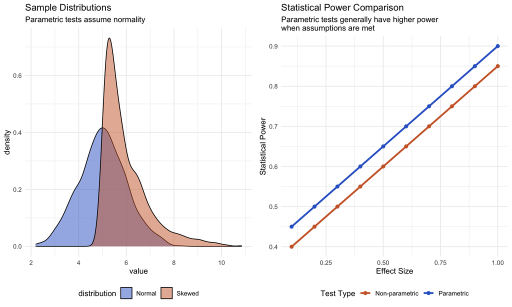

```r
# Create simulated data for demonstration
set.seed(123)
n <- 1000
x_norm <- rnorm(n, mean = 5, sd = 1)
x_skew <- 5 + rexp(n, rate = 1)

# Create a data frame for plotting
df <- data.frame(
  value = c(x_norm, x_skew),
  distribution = rep(c("Normal", "Skewed"), each = n)
)

# Plot distributions
p1 <- ggplot(df, aes(x = value, fill = distribution)) +
  geom_density(alpha = 0.5) +
  scale_fill_manual(values = c("Normal" = "#3366CC", "Skewed" = "#CC6633")) +
  labs(title = "Sample Distributions",
       subtitle = "Parametric tests assume normality") +
  theme_minimal() +
  theme(legend.position = "bottom")

# Create a data frame for power comparison
power_df <- data.frame(
  effect_size = seq(0.1, 1.0, by = 0.1),
  parametric = 0.4 + 0.5 * seq(0.1, 1.0, by = 0.1),
  nonparametric = 0.35 + 0.5 * seq(0.1, 1.0, by = 0.1)
)

power_long <- power_df %>%
  pivot_longer(cols = c(parametric, nonparametric),
               names_to = "test_type",
               values_to = "power")

# Plot power comparison
p2 <- ggplot(power_long, aes(x = effect_size, y = power, color = test_type)) +
  geom_line(size = 1.2) +
  geom_point(size = 2) +
  scale_color_manual(values = c("parametric" = "#3366CC", "nonparametric" = "#CC6633"),
                     labels = c("Non-parametric", "Parametric")) +
  labs(title = "Statistical Power Comparison",
       subtitle = "Parametric tests generally have higher power\nwhen assumptions are met",
       x = "Effect Size",
       y = "Statistical Power",
       color = "Test Type") +
  theme_minimal() +
  theme(legend.position = "bottom")

# Display plots side by side
grid.arrange(p1, p2, ncol = 2)
```

## Examples of Test Selection

### t-test vs. Mann-Whitney U Test

Here we’ll demonstrate how to check assumptions and choose between parametric and non-parametric tests:

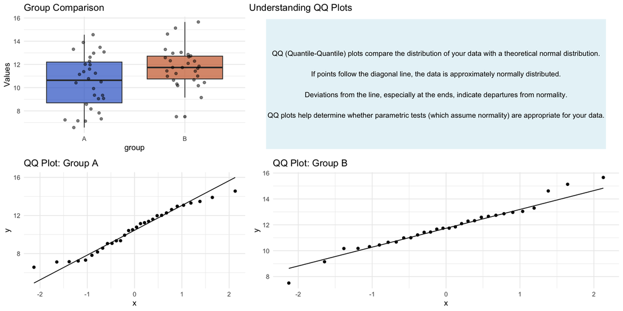

```r
# Generate sample data
set.seed(456)
group_a <- rnorm(30, mean = 10, sd = 2)
group_b <- rnorm(30, mean = 11.5, sd = 2)

# Create a data frame
t_test_df <- data.frame(
  value = c(group_a, group_b),
  group = rep(c("A", "B"), each = 30)
)

# Visualize data with boxplots
p3 <- ggplot(t_test_df, aes(x = group, y = value, fill = group)) +
  geom_boxplot(alpha = 0.7) +
  geom_jitter(width = 0.2, alpha = 0.5) +
  scale_fill_manual(values = c("A" = "#3366CC", "B" = "#CC6633")) +
  labs(title = "Group Comparison",
       y = "Values") +
  theme_minimal() +
  theme(legend.position = "none")

# QQ plot for Group A
p4 <- ggplot(t_test_df[t_test_df$group == "A",], aes(sample = value)) +
  stat_qq() +
  stat_qq_line() +
  labs(title = "QQ Plot: Group A") +
  theme_minimal()

# QQ plot for Group B
p5 <- ggplot(t_test_df[t_test_df$group == "B",], aes(sample = value)) +
  stat_qq() +
  stat_qq_line() +
  labs(title = "QQ Plot: Group B") +
  theme_minimal()

# Create an explanation text plot without using geom_textbox
p6 <- ggplot() +
  annotate("rect", xmin = -1, xmax = 1, ymin = -1, ymax = 1,
           fill = "lightblue", alpha = 0.3) +
  annotate("text", x = 0, y = 0,
           label = "QQ (Quantile-Quantile) plots compare the distribution of your data with a theoretical normal distribution.\n\nIf points follow the diagonal line, the data is approximately normally distributed.\n\nDeviations from the line, especially at the ends, indicate departures from normality.\n\nQQ plots help determine whether parametric tests (which assume normality) are appropriate for your data.",
           size = 3.5, hjust = 0.5, vjust = 0.5) +
  theme_void() +
  labs(title = "Understanding QQ Plots")

# Combine plots
grid.arrange(p3, p6, p4, p5, ncol = 2, widths = c(1, 1.5))
```

```r
# Perform tests
t_test_result <- t.test(value ~ group, data = t_test_df)
wilcox_result <- wilcox.test(value ~ group, data = t_test_df)

cat("t-test result: p =", round(t_test_result$p.value, 4), "\n")
```

```
## t-test result: p = 0.0126
```

```r
cat("Mann-Whitney U test result: p =", round(wilcox_result$p.value, 4), "\n")
```

```
## Mann-Whitney U test result: p = 0.0345
```

### ANOVA vs. Kruskal-Wallis

For comparisons involving more than two groups:

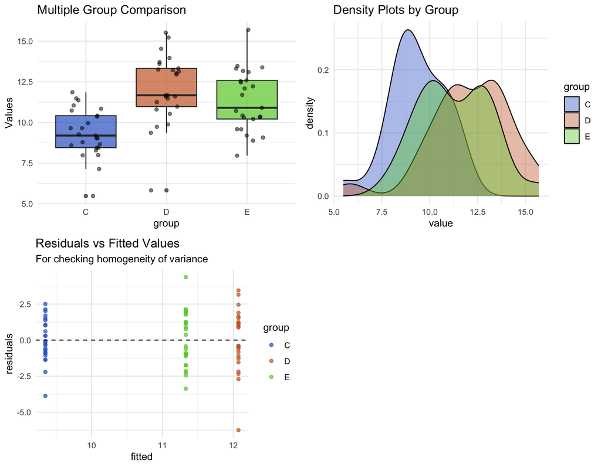

```r
# Generate sample data
set.seed(789)
group_c <- rnorm(25, mean = 10, sd = 2)
group_d <- rnorm(25, mean = 12, sd = 2)
group_e <- rnorm(25, mean = 11, sd = 2)

# Create a data frame
anova_df <- data.frame(
  value = c(group_c, group_d, group_e),
  group = rep(c("C", "D", "E"), each = 25)
)

# Visualize data
p7 <- ggplot(anova_df, aes(x = group, y = value, fill = group)) +
  geom_boxplot(alpha = 0.7) +
  geom_jitter(width = 0.2, alpha = 0.5) +
  scale_fill_manual(values = c("C" = "#3366CC", "D" = "#CC6633", "E" = "#66CC33")) +
  labs(title = "Multiple Group Comparison",
       y = "Values") +
  theme_minimal() +
  theme(legend.position = "none")

# Density plots for each group
p8 <- ggplot(anova_df, aes(x = value, fill = group)) +
  geom_density(alpha = 0.4) +
  scale_fill_manual(values = c("C" = "#3366CC", "D" = "#CC6633", "E" = "#66CC33")) +
  labs(title = "Density Plots by Group") +
  theme_minimal()

# Perform tests
anova_result <- aov(value ~ group, data = anova_df)
kruskal_result <- kruskal.test(value ~ group, data = anova_df)

# Create residual plot for checking homogeneity of variance
anova_df$residuals <- residuals(anova_result)
anova_df$fitted <- fitted(anova_result)

p9 <- ggplot(anova_df, aes(x = fitted, y = residuals)) +
  geom_point(aes(color = group), alpha = 0.7) +
  geom_hline(yintercept = 0, linetype = "dashed") +
  scale_color_manual(values = c("C" = "#3366CC", "D" = "#CC6633", "E" = "#66CC33")) +
  labs(title = "Residuals vs Fitted Values",
       subtitle = "For checking homogeneity of variance") +
  theme_minimal()

# Combine plots
grid.arrange(p7, p8, p9, ncol = 2, nrow = 2)
```

```r
# Display results
cat("ANOVA result: p =", round(summary(anova_result)[[1]]$"Pr(>F)"[1], 4), "\n")
```

```
## ANOVA result: p = 0
```

```r
cat("Kruskal-Wallis result: p =", round(kruskal_result$p.value, 4), "\n")
```

```
## Kruskal-Wallis result: p = 0
```

```r
# Tukey's HSD for post-hoc analysis
if(summary(anova_result)[[1]]$"Pr(>F)"[1] < 0.05) {
  cat("\nPost-hoc analysis (Tukey's HSD):\n")
  print(TukeyHSD(anova_result))
}
```

```
##
## Post-hoc analysis (Tukey's HSD):
##   Tukey multiple comparisons of means
##     95% family-wise confidence level
##
## Fit: aov(formula = value ~ group, data = anova_df)
##
## $group
##           diff        lwr      upr     p adj
## D-C  2.7228427  1.4800694 3.965616 0.0000045
## E-C  1.9812335  0.7384602 3.224007 0.0008241
## E-D -0.7416093 -1.9843826 0.501164 0.3320057
```

## Structured Decision Process for Test Selection

Here’s a step-by-step guide for selecting an appropriate test:

[figure not shown]

```r
# Create data for a more detailed decision tree
decisions <- data.frame(
  x = c(1:20, 1:20, 1:20),
  y = rep(c(1, 2, 3), each = 20),
  label = c(
    # Level 1 - Data type
    "Is your data categorical or continuous?", rep(NA, 19),
    # Level 2 - Branches by data type
    "Categorical", "Continuous", rep(NA, 18),
    # Level 3 - More specific questions
    "How many variables?", "Normality check?", "How many groups?",
    "What's your question?", rep(NA, 16)
  )
)

# Remove NA labels
decisions <- decisions[!is.na(decisions$label), ]

# Create visual
ggplot(decisions, aes(x = x, y = y)) +
  # Add the decision points as text
  geom_text(aes(label = label), size = 4) +
  # Add arrows connecting decision points
  geom_segment(aes(x = 1, y = 3, xend = 1, yend = 2),
               arrow = arrow(length = unit(0.2, "cm")), size = 0.8) +
  geom_segment(aes(x = 1, y = 2, xend = 1, yend = 1),
               arrow = arrow(length = unit(0.2, "cm")), size = 0.8) +
  geom_segment(aes(x = 1, y = 2, xend = 2, yend = 1),
               arrow = arrow(length = unit(0.2, "cm")), size = 0.8) +
  # Customize appearance
  xlim(0, 10) +
  ylim(0, 4) +
  theme_void() +
  theme(plot.title = element_text(hjust = 0.5, size = 16)) +
  labs(title = "First Steps in Statistical Test Selection")
```

## Statistical Test Selection Guide

This comprehensive decision matrix helps you select the appropriate statistical test based on your data characteristics and research question:

[figure not shown]

```r
# Create a visual guide for test selection
test_matrix <- data.frame(
  x = rep(1:5, each = 4),
  y = rep(4:1, times = 5),
  test = c(
    # Column 1 - Categorical
    "Chi-square\nGoodness-of-fit",
    "Chi-square\nIndependence",
    "Fisher's exact\ntest",
    "McNemar's test",

    # Column 2 - One sample continuous
    "One-sample\nt-test",
    "Wilcoxon\nsigned-rank",
    "Binomial test",
    "Sign test",

    # Column 3 - Two samples continuous
    "Independent\nt-test",
    "Paired\nt-test",
    "Mann-Whitney\nU test",
    "Wilcoxon\nsigned-rank",

    # Column 4 - Multi-sample continuous
    "One-way\nANOVA",
    "Repeated measures\nANOVA",
    "Kruskal-Wallis\ntest",
    "Friedman\ntest",

    # Column 5 - Relationships
    "Pearson's\ncorrelation",
    "Linear\nregression",
    "Spearman's\ncorrelation",
    "Logistic\nregression"
  ),
  type = c(
    rep("Categorical", 4),
    rep("Continuous\n(one sample)", 4),
    rep("Continuous\n(two samples)", 4),
    rep("Continuous\n(3+ samples)", 4),
    rep("Relationship", 4)
  ),
  parametric = c(
    rep(c("Parametric", "Non-parametric"), times = 10)
  )
)

# Plot the matrix
ggplot(test_matrix, aes(x = x, y = y)) +
  # Add background tiles
  geom_tile(aes(fill = type), alpha = 0.3, color = "gray") +
  # Add test names
  geom_text(aes(label = test, color = parametric),
            size = 3.5, fontface = "bold") +
  # Set colors and labels
  scale_fill_manual(values = c("lightblue", "lightgreen", "lightyellow",
                              "lightpink", "lightsalmon")) +
  scale_color_manual(values = c("blue4", "darkred")) +
  scale_x_continuous(breaks = 1:5,
                    labels = c("Categorical", "One sample\ncontinuous",
                              "Two samples\ncontinuous", "Multi-sample\ncontinuous",
                              "Relationships")) +
  scale_y_continuous(breaks = 1:4,
                    labels = c("Related\nsamples", "Independent\nsamples",
                              "Normal data", "Non-normal\ndata")) +
  # Set theme and labels
  theme_minimal() +
  theme(axis.text = element_text(face = "bold"),
        legend.position = "bottom",
        plot.title = element_text(hjust = 0.5, size = 16)) +
  labs(title = "Statistical Test Selection Matrix",
       x = "Data Type and Research Question",
       y = "Assumptions and Sample Type",
       fill = "Category",
       color = "Test Type")
```

## Comprehensive Test Selection Table

| Test | DataType | Groups | Parametric | KeyAssumptions | UseWhen |
| --- | --- | --- | --- | --- | --- |
| Chi-square test | Categorical | Two+ | No | Expected counts ≥5 | Comparing proportions with adequate sample |
| Fisher’s exact test | Categorical | Two | No | Small sample size | Small sample or sparse data |
| Independent t-test | Continuous | Two | Yes | Normality, Equal variances | Comparing means of independent samples with equal variance |
| Welch’s t-test | Continuous | Two | Yes | Normality, Unequal variances | Comparing means with unequal variances |
| Paired t-test | Continuous | Two (paired) | Yes | Normally distributed differences | Comparing means of paired samples |
| One-sample t-test | Continuous | One | Yes | Normality | Comparing mean to known value |
| Mann-Whitney U | Continuous | Two | No | Continuous distribution | Comparing independent samples, non-normal data |
| Wilcoxon signed-rank | Continuous | Two (paired) | No | Continuous distribution | Comparing paired samples, non-normal data |
| One-way ANOVA | Continuous | Three+ | Yes | Normality, Equal variances | Comparing three+ groups with equal variance |
| Kruskal-Wallis | Continuous | Three+ | No | Continuous distribution | Comparing three+ groups, non-normal data |
| Repeated measures ANOVA | Continuous | Three+ (repeated) | Yes | Sphericity | Comparing repeated measures across three+ conditions |
| Friedman test | Continuous | Three+ (repeated) | No | Ordered data | Comparing repeated measures, non-normal or ordinal data |
| Pearson correlation | Continuous | N/A | Yes | Bivariate normality, Linear relationship | Assessing linear relationship between variables |
| Spearman correlation | Continuous | N/A | No | Monotonic relationship | Assessing monotonic relationship, non-normal or ordinal data |

## Conclusion

When selecting a statistical test, remember these key principles:

1. **Identify your variables’ types** (categorical or continuous)
2. **Clarify your research question** (comparison or relationship)
3. **Check assumptions carefully**
   - For continuous data: normality, homogeneity of variance
   - For categorical data: expected cell counts
4. **Consider sample size** - affects robustness and power
5. **Choose between parametric and non-parametric approaches** based on assumptions
6. **For significant results, conduct appropriate post-hoc tests**

By following this structured approach, you can select the most appropriate statistical test for your specific research scenario.